# CopyKAT: Rhabdomyosarcoma cell type tumor vs normal inference for SCPCL000488

This notebook explores performance of the [`copyKat`](https://github.com/navinlabcode/copykat) package for calling tumor vs. normal cells in pediatric cancer scRNA-seq data. Specifically, we look at a library from the `SCPCP000005` (RMS) project, where the submitter has annotated cell types which we can consider “ground truth” for the purposes of this exploration. We’ll assess agreement between the submitter tumor/normal classification and what `copyKat` infers as tumor/normal, across some different `copyKat` parameter values.

## Background: `copyKat` method

Reference: https://doi.org/10.1038/s41587-020-00795-2

To begin, here’s a brief overview of the `copyKat` approach, partly quoting the paper throughout. See Figure 1 in the paper for a method diagram:

- `copyKat` takes the *raw expression matrix* and stabilizes variance, smooths the outliers
- A subset of cells is then identified to serve as a diploid baseline for subsequent identification of diploid/aneuploid
  - Cells are pooled into clusters with hierarchical clustering, and a GMM estimtes variance of each cluster
  - Cluster with minimal estimated variance is regarded as the “confident diploid cells”
  - **Caution:** This may fail if data has few normal cells and/or there are few CNA events. A “GMM definition mode” (sic; I think they meant “model”!) is offered to deal with this (described in paper bottom of pg 599), but implementation details to invoke this mode are thin. I *think* it is automatically applied?
- MCMC is used to identify chromosome breakpoints with KS tests between gene windows
  - Significant test = probably a breakpoint
  - Final copy numbers for each window are the posterior means of all genes spanning breakpoints
  - These values are converted to genomic positions in 220-kb bins. *`copyKat` ultimately provides these values in the outputted CNA matrix.*
- Hierarchical clustering identifies largest distance between aneuploid and diploid, but if distance not significant, they switch to the “GMM definition model” to predict tumor cells one-by-one.
- Finally, clustering delineates clonal substructure (not particularly relevant to us) for differential expression.

## Set Up

```r
suppressPackageStartupMessages({
  library(SingleCellExperiment)
  library(ggplot2)
  library(copykat) # https://github.com/navinlabcode/copykat
})
theme_set(theme_bw())

# define output path and SCE file
output_dir <-  here::here("celltype_annotation",
                          "analysis",
                          "copykat-results")
fs::dir_create(output_dir)

# TSV output file that compares results for different distance parameters
copykat_distance_tsv <- file.path(output_dir,
                                glue::glue("{params$library}_copykat_results_distance_parameters.tsv"))

# Output file that compares results for different kscut parameters
copykat_kscut_tsv <- file.path(output_dir,
                                glue::glue("{params$library}_copykat_results_kscut_parameters.tsv"))
```

The next chunk defines some functions for running `copyKat` and analyzing results.

```r
# function to run copyKat over a user-provided range of parameter values
run_copykat_over_params <- function(raw_counts_matrix,
                                    # specify defaults in overall function
                                    distance_param = "euclidian",
                                    kscut_param    =  0.1,
                                    threads = params$threads,
                                    sample_name = params$library_id,
                                    output_directory = output_dir,
                                    copykat_df = NULL,
                                    output_tsv = NULL) {

  # argument checks
  if (is.null(copykat_df)) {
    stop("Need an initiated data frame to run `run_copykat`.")
  }

  if (is.null(output_tsv)) {
    stop("Need a value for `output_tsv`.")
  }

  # ONLY one of the parameters can have a range of values!
  if (length(distance_params) > 1 & length(kscut_params) > 1) {
    stop("The `run_copykat_over_params` function needs to vary one of the parameters.")
  }

  # Or, run with purrr::map() for a range of values and then cbind results at the end

    ### distance ####
    if (length(distance_params) > 1) {

      copykat_names <- glue::glue("copykat_{distance_params}") # for assigning TSV column names names later

      copykat_results <- purrr::map(
        distance_params,
        \(distance_parameter) {

          copykat_result <- copykat(
            rawmat = as.matrix(counts(sce)),
            id.type = "E", # we have Ensembl gene ids, not the default gene symbols ("S")
            sam.name = glue::glue("{params$library_id}-{distance_parameter}"), # unique name for each
            distance = distance_parameter,
            ks.cut = kscut_param, # use default, but write out to be explicit
            # attempt to turn off some outputs..
            plot.genes = FALSE,
            output.seg = FALSE,
            n.cores = params$threads
          )

          # return predictions
          return(copykat_result$prediction$copykat.pred)
      })
    } else {
      ### ks.cut ####
      copykat_names <- glue::glue("copykat_{kscut_params}") # for assigning TSV column names names later

      ### kscut ###
      copykat_results <- purrr::map(
          kscut_params,
          \(kscut_parameter) {

            copykat_result <- copykat(
              rawmat = as.matrix(counts(sce)),
              id.type = "E", # we have Ensembl gene ids, not the default gene symbols ("S")
              sam.name = glue::glue("{params$library_id}-{distance_parameter}"), # unique name for each
              distance = distance_param, # use default, but write out to be explicit
              ks.cut = kscut_parameter,
              # attempt to turn off some outputs..
              plot.genes = FALSE,
              output.seg = FALSE,
              n.cores = params$threads
            )

            # return predictions
            return(copykat_result$prediction$copykat.pred)
      })
    }

    # name the results
    names(copykat_results) <- copykat_names

    # Bind up all the columns
     copykat_df <- dplyr::bind_cols(
       copykat_df,
       copykat_results
     ) |>
      # remove submitter NAs
    tidyr::drop_na(submitter)
}





# function to compare copykat results across values for _one_ varied parameter
#   with a barplot
compare_copykat_results_barplot <- function(copykat_df) {

  # prepare data frame for plotting
  copykat_df_long <- copykat_df |>
    tibble::rowid_to_column(var = "cell") |>
    tidyr::pivot_longer(
      contains("copykat"),
      names_to = "copykat_parameter",
      values_to = "prediction"
    ) |>
    dplyr::mutate(copykat_parameter = stringr::str_replace(copykat_parameter,
                                                         "copykat_", ""))

  # make, return a barplot of predictions
  ggplot(copykat_df_long) +
    aes(x = submitter_binary, fill = prediction) +
    geom_bar(position = "fill",
             # use alpha to see background grid
             alpha = 0.75) +
    facet_grid(vars(copykat_parameter)) +
    labs(
      x = "Submitter annotation",
      y = "Proportion of cells",
      fill = "CopyKat prediction"
    ) +
    # add guideline at y=0.5
    geom_hline(yintercept = 0.5, alpha = 0.25)
}



# function to compare result tables both via overall counts and confusion matrix
compare_result_tables <- function(copykat_result_column, df, output_dir, output_name) {
  # Takes data frame (_second argument_) with three columns with fully defined values:
  ### `submitter`: full submitter annotations
  ### `submitter_binary`: submitter annotations reduced to tumor/normal only
  #### `copykat_result_column` (first argument): column containing copykat annotations,
  #       considering only diploid/aneuploid
  # `output_dir` and `output_name` are the directory and name to use for saving an RDS file
  #  with confusion matrix results
  # Returns overall table comparison and result from caret::confusionMatrix()

  cat(glue::glue("\n\n================== {copykat_result_column} ===================="))

  # copy the column for convenience
  df$copykat <- df[[copykat_result_column]]

  # Result 1: Table comparing full results
  print(
    table(df$submitter, df$copykat)
  )

  # Result 2: confusion matrix
  cat("\n")

  # remove "not.defined" from copyKat and update levels
  df_caret <- df |>
    dplyr::filter(copykat != "not.defined") |>
    # copykat values need to match submitter_binary values
    dplyr::mutate(copykat = ifelse(
      # use str_detect for test data
      stringr::str_detect(copykat,"diploid"), "Normal", "Tumor"
    )) |>
    # Tumor should be first as the "positive" value
    dplyr::mutate(
      copykat = forcats::fct_relevel(copykat, "Tumor"),
      submitter_binary = forcats::fct_relevel(submitter_binary, "Tumor")
    )

  confusion <-  caret::confusionMatrix(
    table(df_caret$submitter_binary,
          df_caret$copykat)
  )
  print(confusion)

  # Save to file
  readr::write_rds(
    confusion,
    file.path(output_dir, glue::glue("{output_name}_{copykat_result_column}_confusion-matrix.rds"))
  )
}
```

In the next chunk, we obtain the *submitter-annotated* SCE from S3, if it is not already locally present.

```r
# make local data directory if it doesn't exist
if (!dir.exists(params$local_data_dir)) {
  dir.create(params$local_data_dir, recursive = TRUE)
}

# build path to submitter annotated sce file
submitter_annotated_sce_file <- glue::glue("{params$library_id}_processed_celltype.rds")


local_submitter_sce_path <- file.path(params$local_data_dir,
                                      params$sample_id,
                                      submitter_annotated_sce_file)

# get submitter sce from S3 if not already present locally
if (!(file.exists(local_submitter_sce_path))) {
  sync_call <- glue::glue('op run -- aws s3 sync {params$s3_submitter_data_dir} {params$local_data_dir}/{params$sample_id} --exclude "*" --include "{submitter_annotated_sce_file}"')
  system(sync_call, ignore.stdout = TRUE)
}
```

Now, we’ll read in the SCE and prepare for `copyKat` inference.

```r
# read in initial SCE
sce <- readr::read_rds(local_submitter_sce_path)

# use a small SCE for testing, if specified
if (params$test) {
  sce <- sce[, 1:50]
}

# pull out count matrix
raw_counts <- counts(sce)

# Initiate TSV for storing results
copykat_df <- tibble::tibble(
  submitter = sce$celltype,
  # and a binary version for later classification assessment
  submitter_binary = ifelse(
  stringr::str_starts(submitter, "Tumor"),
    "Tumor",
    "Normal"
  )
)

# Now we can remove the SCE
rm(sce)
```

Let’s first get a sense of balance in the data from the submitter annotations:

```r
table(copykat_df$submitter_binary)
```

```
Normal  Tumor
   742   5128
```

## Compare CopyKAT distance parameters

### Run copyKat

The `copyKat` [GitHub `README` file](https://github.com/navinlabcode/copykat/blob/b795ff793522499f814f6ae282aad1aab790902f/README.md?plain=1#L67) includes this caveat about the `"distance"` parameter:

> One struggling observation is that none of one clustering method could fit all datasets. In this version, I add a distance parameters for clustering that include “euclidean” distance and correlational distance, ie. 1-“pearson” and “spearman” similarity. In general, corretional distances tend to favor noisy data, while euclidean distance tends to favor data with larger CN segments.

Therefore we’ll begin by comparing `"euclidean"`, `"spearman"`, and `"pearson"` values for [this parameter](https://github.com/navinlabcode/copykat/blob/b795ff793522499f814f6ae282aad1aab790902f/R/copykat.R#L251-L255).

```r
# Only run copykat if the final TSV does not exist
if (file.exists(copykat_distance_tsv)) {

  copykat_df <- readr::read_tsv(copykat_distance_tsv)

} else {

  distance_parameters <- c("spearman", "pearson", "euclidan")

  # run and save final predictions to the df, which is also exported as TSV
  copykat_df <- run_copykat_over_params(raw_counts,
                                        distance_param = distance_parameters,
                                        copykat_df = copykat_df,
                                        output_tsv = copykat_distance_tsv)

}
```

### Comparing results

We’ll begin with a barplot of tumor/normal classifications across `copyKat` parameters:

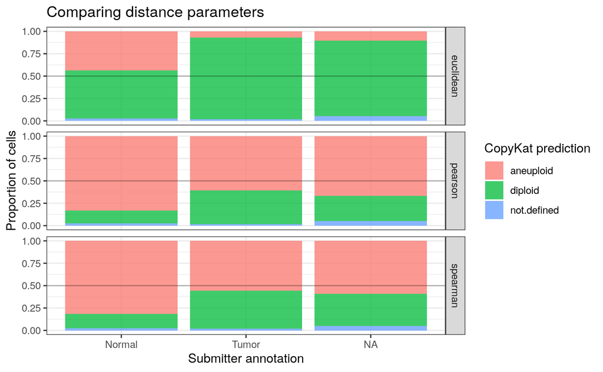

```r
# Plot the data:
compare_copykat_results_barplot(copykat_df) +
  ggtitle("Comparing distance parameters")
```

Next, we’ll look at tables for correspondence between submitter cell type annotations and `copyKat` inferences, as well as confusion matrix results for each comparison. For `copyKat`, “diploid” is normal and “aneuploid” is tumor.

Among the statistics reported in the confusion matrix, we are particularly interested in these:

- **Kappa**: Quantifies agreement in a classification model, where close to 1 is nearly perfect, and less than 0 is worse agreement that random chance.
- **Balanced accuracy**: Averaged accuracy across both minority and majority classes; a more robust measure of accuracy for imbalanced data like we have here. Ranges from 0-1.

We’d like to see high kappa and balanced accuracy values, each close to 1.

```r
purrr::walk(
  # column names of interest
  names(copykat_df)[stringr::str_starts(names(copykat_df), "copykat_")],
  compare_result_tables,
  # shared arguments
  copykat_df,
  output_dir,
  params$library_id
)
```

```
================== copykat_euclidean ====================
                       aneuploid diploid not.defined
  Fibroblast                  28      34           0
  Lymphocyte                  29      88          10
  Monocyte                    87     102           6
  Neuron                       8      81           0
  Tumor_Mesoderm              60     160           8
  Tumor_Myoblast-A             7      68           0
  Tumor_Myoblast-B             4      34           4
  Tumor_Myoblast-C           196    3213          66
  Tumor_Myoblast-D             6     111           8
  Tumor_Myocyte-A             42     498           5
  Tumor_Myocyte-B             49     583           6
  Vascular Endothelium       173      93           3

Confusion Matrix and Statistics


         Tumor Normal
  Tumor    364   4667
  Normal   325    398

               Accuracy : 0.1324
                 95% CI : (0.1238, 0.1415)
    No Information Rate : 0.8803
    P-Value [Acc > NIR] : 1

                  Kappa : -0.1056

 Mcnemar's Test P-Value : <2e-16

            Sensitivity : 0.52830
            Specificity : 0.07858
         Pos Pred Value : 0.07235
         Neg Pred Value : 0.55048
             Prevalence : 0.11974
         Detection Rate : 0.06326
   Detection Prevalence : 0.87435
      Balanced Accuracy : 0.30344

```

[output cut: 72 more lines]

```

                  Kappa : -0.1405

 Mcnemar's Test P-Value : <2e-16

            Sensitivity : 0.82470
            Specificity : 0.05094
         Pos Pred Value : 0.56669
         Neg Pred Value : 0.16183
             Prevalence : 0.60080
         Detection Rate : 0.49548
   Detection Prevalence : 0.87435
      Balanced Accuracy : 0.43782

       'Positive' Class : Tumor
```

## Compare CopyKAT KS.cut parameters

### Run copyKat

In the previous section, we saw that correlational distance is likely to be better than euclidean. In this section, we’ll again run `copyKat`, **but this time using *only* the “pearson” distance**, at a variety of `KS.cut` parameters.

As described in the [GitHub `README` file](https://github.com/navinlabcode/copykat/blob/b795ff793522499f814f6ae282aad1aab790902f/README.md?plain=1#L61),

> KS.cut is the segmentation parameter, ranging from 0 to 1. Increasing KS.cut decreases sensitivity, i.e. less segments/breakpoints. Usually it works in a range of 0.05-0.15.

For this, we’ll start with the SCE from the last section, and build it up from there with other `KS.cut` values. Since it was already run with default `KS.cut = 0.1`, we’ll test a few additional values here and compare those to above.

```r
if (file.exists(copykat_kscut_tsv)) {
  # if the TSV exists, read it in
  copykat_df <- readr::read_tsv(copykat_kscut_tsv)

} else if (file.exists(copykat_distance_tsv)) {

  # if only the _distance_ tsv exists, read in as a starting point
  copykat_df <- readr::read_tsv(copykat_distance_tsv)

  # clean up columns for this analysis
  copykat_df <- copykat_df |>
    dplyr::select(
      contains("submitter"),
      copykat_0.1 = copykat_pearson
    )

  kscut_parameters <- seq(0.025, 0.15, 0.025)[-4] # can skip 0.1

  # run and save final predictions to the df, which is also exported as TSV
  copykat_df <- run_copykat_over_params(raw_counts,
                                        kscut_param = kscut_parameters,
                                        copykat_df = copykat_df,
                                        output_tsv = copykat_kscut_tsv)
} else {
  stop("Error: At least one of those TSV files should have existed by now!")
}
```

### Comparing results

As before, begin with a barplot of tumor/normal classifications across `copyKat` parameters:

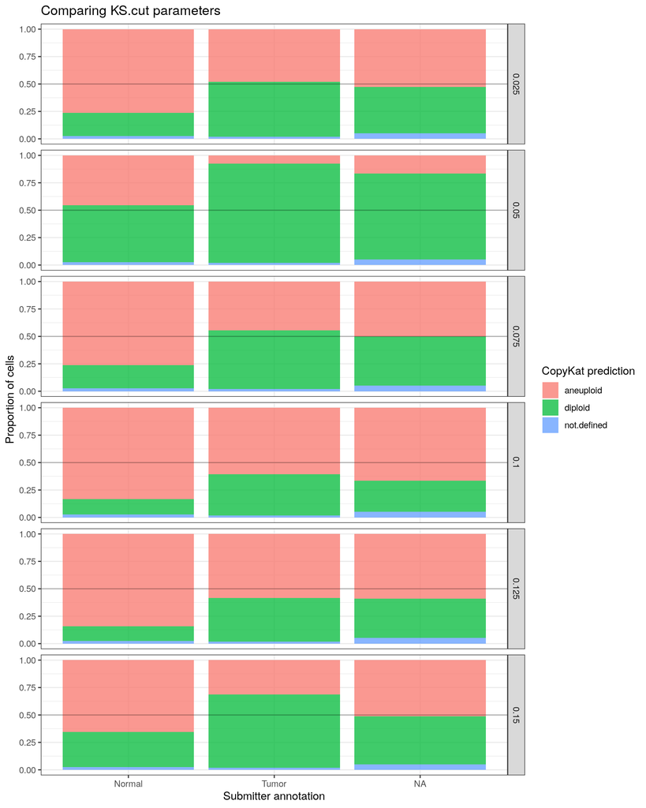

```r
# Plot the data:
compare_copykat_results_barplot(copykat_df) +
  ggtitle("Comparing KS.cut parameters")
```

Next, we’ll look at tables for correspondence between submitter cell type annotations and `copyKat` inferences, as well as confusion matrix results for each comparison. For `copyKat`, “diploid” is normal and “aneuploid” is tumor.

As before, for the confusion matrix results, we’d like to see `kappa` and `balanced accuracy` values be close to 1, and we definitely don’t want to see negative `kappa` values.

```r
purrr::walk(
  # column names of interest
  names(copykat_df)[stringr::str_starts(names(copykat_df), "copykat_")],
  compare_result_tables,
  # shared arguments
  copykat_df,
  output_dir,
  params$library_id
)
```

```
================== copykat_0.025 ====================
                       aneuploid diploid not.defined
  Fibroblast                  52      10           0
  Lymphocyte                  91      26          10
  Monocyte                   151      38           6
  Neuron                      36      53           0
  Tumor_Mesoderm             177      43           8
  Tumor_Myoblast-A            43      32           0
  Tumor_Myoblast-B            19      19           4
  Tumor_Myoblast-C          1405    2004          66
  Tumor_Myoblast-D            79      38           8
  Tumor_Myocyte-A            242     298           5
  Tumor_Myocyte-B            500     132           6
  Vascular Endothelium       237      29           3

Confusion Matrix and Statistics


         Tumor Normal
  Tumor   2465   2566
  Normal   567    156

               Accuracy : 0.4555
                 95% CI : (0.4426, 0.4685)
    No Information Rate : 0.5269
    P-Value [Acc > NIR] : 1

                  Kappa : -0.1348

 Mcnemar's Test P-Value : <2e-16

            Sensitivity : 0.81299
            Specificity : 0.05731
         Pos Pred Value : 0.48996
         Neg Pred Value : 0.21577
             Prevalence : 0.52694
         Detection Rate : 0.42840
   Detection Prevalence : 0.87435
      Balanced Accuracy : 0.43515

```

[output cut: 201 more lines]

```

                  Kappa : -0.1286

 Mcnemar's Test P-Value : <2e-16

            Sensitivity : 0.76727
            Specificity : 0.06485
         Pos Pred Value : 0.31783
         Neg Pred Value : 0.32918
             Prevalence : 0.36218
         Detection Rate : 0.27789
   Detection Prevalence : 0.87435
      Balanced Accuracy : 0.41606

       'Positive' Class : Tumor
```

## Conclusions

For *all* inferences performed here, *all* `kappa` values are negative, implying worse performance than a random classifier, and balanced accuracy was never higher than ~0.44. The performance was best (in terms of balanced accuracy) when using correlational distance (spearman or pearson) vs euclidian, and there were not strong differences across values of `KS.cut` parameters. Regardless of some improvements under certain parameterizations, performance was overall poor on this data.

It is also worth noting some aspects of the `copyKat` package:

- `copyKat` [hardcodes a random seed](https://github.com/navinlabcode/copykat/blob/b795ff793522499f814f6ae282aad1aab790902f/R/copykat.R#L29-L32) so we can’t readily assess bias from starting conditions.
- It emits *a lot of output*, and we don’t have much control over it!
  - This includes both `print()` statements and output files, some of which are optional but not all; and it seems the optional ones may still be exported even if you turn them off?
  - The *lots and lots of output* is not seen in this notebook because it was rendered after files already existed; the output *cannot* be suppressed by turning off warnings or messages, because they are all print statements.
  - Of this output, we get a `"cell: #"` printed for each cell, and we also see that the majority also have a printed statement: `"WARNING! NOT CONVERGENT!"`. This latter statement is *printed* from a [dependency](https://github.com/cran/mixtools/blob/4af1e2789bcea7df3c1775a53cd05b37ec3185d0/R/normalmixEM.R#L129-L131) during the `copyKat` step to identify a baseline diploid cell population.
- There is no clear way to assess confidence from `copyKat` output.
  - *That said*, when you run this notebook with the test parameter as `TRUE`, you may notice that cells are no longer annotated `"diploid"` or `"aneuploid"` but instead as `"c1:diploid:low.conf"` and `"c2:aneuploid:low.conf"`, respectively. For the test runs, `copyKat` was unable to determine a reliable baseline for diploid cells, so everything was annotated as unreliable
  - This is a form of a “confidence,” and as the full SCE does not give these `"low.conf"` annotations, that tells us that `copyKat` feels confident in the results run on the full SCE.

Based on these drawbacks, if we want to use `copyKat` moving forward, we might consider forking the repository and modifying aspects that best suit our needs:

- More control over the seed
- Less printing and fewer output files, where possible